# 2017-2018学年第二学期期中教学检查

周丹

2018/5/27

# 1 教师上课情况统计

统计表中有如下指标：

- 在编教师数 在编教师数(高级) 在编教师数(高级占比)
- 进修教师数 进修教师数(高级) 进修教师(高级占比)
- 授课教师数 授课教师数(高级) 授课教师数(高级占比)
- 授课门数 授课门数(高级) 授课门数(高级占比)
- 授课班级数 授课班级数(高级) 授课班级数(高级占比)

其中主讲本科生课程的教授人数为235人，占全部在编专任教师的 12.51%，占在编教授中的54.15%；

教授人均授课1.07 门， 人均授课课2.4个教学班。

其中主讲本科生课程的副教授人数为468人，占全部在编专任教师的 24.91%，占在编副教授中的65.73%；

副教授人均授课0.93 门， 人均授课课0.95教学班。

其中,主讲本科生课程的教授和副教授人数最多的学院是资环学院 ，教授、副教授中主讲本科生课程最少的学院为创新学院。

本学期外聘教师8人，共承担11门本科生课程；参加培训进修、境内外交流的人数达206人，交流的人数最多的学院为风景艺术学院。没有参加培训进修、境内外交流的学院是创新学院和体育部 。

## 1.1 教师上课情况统计1

表1.1: 教师上课情况统计1(n=22)

| 序号 | 学院 | 在编教师中高级职称占比% | 授课教师中高级职称占比%) | 高级职称中授课教师比率% | 教授中授课教师比率% | 副教授中授课教师比率% |
| --- | --- | --- | --- | --- | --- | --- |
| 1 | 农学院 | 69 | 65 | 31 | 43 | 46 |
| 2 | 植保学院 | 77 | 73 | 45 | 57 | 62 |
| 3 | 园艺学院 | 58 | 50 | 26 | 39 | 55 |
| 4 | 动科学院 | 71 | 77 | 32 | 33 | 53 |
| 5 | 动医学院 | 72 | 76 | 40 | 53 | 58 |
| 6 | 林学院 | 70 | 76 | 42 | 61 | 60 |
| 7 | 风景艺术学院 | 37 | 36 | 34 | 88 | 93 |
| 8 | 资环学院 | 70 | 76 | 59 | 85 | 84 |
| 9 | 水建学院 | 69 | 67 | 37 | 39 | 61 |
| 10 | 机电学院 | 45 | 53 | 37 | 100 | 76 |
| 11 | 信息学院 | 55 | 46 | 36 | 57 | 69 |
| 12 | 食品学院 | 75 | 85 | 46 | 57 | 65 |
| 13 | 葡萄酒学院 | 64 | 70 | 50 | 88 | 70 |
| 14 | 生命学院 | 64 | 59 | 15 | 19 | 25 |
| 15 | 理学院 | 41 | 44 | 34 | 83 | 84 |
| 16 | 化药学院 | 63 | 64 | 32 | 42 | 56 |
| 17 | 经管学院 | 63 | 61 | 45 | 61 | 79 |
| 18 | 人文学院 | 73 | 60 | 70 | 100 | 96 |
| 19 | 外语系 | 27 | 26 | 25 | 100 | 92 |
| 20 | 创新学院 | 0 | 0 | 0 | 0 | 0 |
| 21 | 马克思学院 | 55 | 55 | 55 | 100 | 100 |
| 22 | 体育部 | 55 | 54 | 53 | 100 | 96 |

## 1.2 教师上课情况统计2

表1.2: 教师上课情况统计2(n=22)

| 序号 | 学院 | 授课课程(高级职称占比%) | 授课班级(高级职称占比%) | 教授人均授课门数 | 副教授人均授课门数 | 教授人均授课班级数 | 副教授人均授课班级数 |
| --- | --- | --- | --- | --- | --- | --- | --- |
| 1 | 农学院 | 64 | 67 | 0.69 | 0.56 | 0.81 | 0.52 |
| 2 | 植保学院 | 69 | 71 | 0.94 | 0.80 | 1.12 | 0.80 |
| 3 | 园艺学院 | 47 | 49 | 0.77 | 1.25 | 1.38 | 1.50 |
| 4 | 动科学院 | 77 | 83 | 0.82 | 0.84 | 1.18 | 1.40 |
| 5 | 动医学院 | 69 | 76 | 0.88 | 1.04 | 2.00 | 2.80 |
| 6 | 林学院 | 74 | 71 | 1.16 | 1.20 | 2.26 | 1.92 |
| 7 | 风景艺术学院 | 33 | 36 | 1.43 | 1.79 | 2.57 | 2.71 |
| 8 | 资环学院 | 76 | 75 | 1.00 | 1.00 | 2.26 | 2.14 |
| 9 | 水建学院 | 62 | 61 | 1.00 | 0.95 | 1.15 | 1.24 |
| 10 | 机电学院 | 57 | 54 | 1.23 | 1.36 | 3.08 | 4.05 |
| 11 | 信息学院 | 50 | 43 | 1.00 | 0.85 | 1.50 | 1.85 |
| 12 | 食品学院 | 89 | 91 | 1.46 | 1.15 | 7.00 | 5.60 |
| 13 | 葡萄酒学院 | 64 | 61 | 0.71 | 0.57 | 1.00 | 0.57 |
| 14 | 生命学院 | 47 | 61 | 0.57 | 0.33 | 3.00 | 2.07 |
| 15 | 理学院 | 53 | 45 | 1.20 | 0.38 | 5.60 | 5.42 |
| 16 | 化药学院 | 69 | 66 | 0.70 | 0.50 | 4.00 | 3.14 |
| 17 | 经管学院 | 56 | 51 | 2.16 | 1.91 | 1.42 | 1.76 |
| 18 | 人文学院 | 56 | 56 | 1.50 | 1.26 | 2.75 | 2.48 |
| 19 | 外语系 | 53 | 35 | 1.00 | 0.65 | 3.25 | 3.96 |
| 20 | 创新学院 | 0 | 0 | 0.00 | 0.00 | 0.00 | 0.00 |
| 21 | 马克思学院 | 67 | 71 | 0.60 | 0.28 | 4.60 | 12.50 |
| 22 | 体育部 | 50 | 54 | 0.50 | 0.09 | 5.25 | 6.09 |

## 1.3 教师上课情况统计3

表1.3: 教师上课情况统计3(n=22)

| 序号 | 学院 | 进修教师数 | 外聘教师授课人数 | 外聘教师授课门数 |
| --- | --- | --- | --- | --- |
| 1 | 农学院 | 8 | 0 | 0 |
| 2 | 植保学院 | 5 | 0 | 0 |
| 3 | 园艺学院 | 2 | 0 | 0 |
| 4 | 动科学院 | 9 | 0 | 0 |
| 5 | 动医学院 | 2 | 0 | 0 |
| 6 | 林学院 | 8 | 0 | 0 |
| 7 | 风景艺术学院 | 59 | 0 | 0 |
| 8 | 资环学院 | 4 | 1 | 1 |
| 9 | 水建学院 | 11 | 0 | 0 |
| 10 | 机电学院 | 5 | 0 | 0 |
| 11 | 信息学院 | 2 | 0 | 0 |
| 12 | 食品学院 | 46 | 5 | 8 |
| 13 | 葡萄酒学院 | 12 | 0 | 0 |
| 14 | 生命学院 | 1 | 0 | 0 |
| 15 | 理学院 | 7 | 0 | 0 |
| 16 | 化药学院 | 7 | 1 | 1 |
| 17 | 经管学院 | 2 | 0 | 0 |
| 18 | 人文学院 | 5 | 0 | 0 |
| 19 | 外语系 | 7 | 1 | 1 |
| 20 | 创新学院 | 0 | 0 | 0 |
| 21 | 马克思学院 | 4 | 0 | 0 |
| 22 | 体育部 | 0 | 0 | 0 |

# 2 听课及领导重视情况

全校院系共有处级干部124人，听课共计209门次，人均听课1.69门次,院系平均听课9.5门次；

学院教学督导听课共计444门次，院系平均听课20.18门次；

学院同行专家听课共计532门次，院系平均听课24.18门次。

学院（系）总平均听课门次为53.86门次，听课次数最多的为水建学院123 门次，其次为马克思主义学院（109门次），最少的为农学院13门次。

本学期共开教学工作会议111次，平均每学院5次会议。教学会议最多的学院为人文学院共13次，其次为信息学院和食品学院，均为10次。

## 2.1 听课情况

听课情况统计表如下

表2.1: 听课情况统计(n=22)

| 序号 | 学院 | 教学督导听课 | 同行专家听课 | 领导听课 | 听课总计 |
| --- | --- | --- | --- | --- | --- |
| 9 | 水建学院 | 66 | 38 | 19 | 123 |
| 21 | 马克思学院 | 32 | 67 | 10 | 109 |
| 4 | 动科学院 | 84 | 7 | 5 | 96 |
| 3 | 园艺学院 | 24 | 56 | 2 | 82 |
| 6 | 林学院 | 20 | 34 | 21 | 75 |
| 22 | 体育部 | 24 | 41 | 6 | 71 |
| 11 | 信息学院 | 12 | 41 | 15 | 68 |
| 16 | 化药学院 | 8 | 46 | 6 | 60 |
| 14 | 生命学院 | 26 | 20 | 9 | 55 |
| 18 | 人文学院 | 27 | 17 | 11 | 55 |
| 2 | 植保学院 | 12 | 21 | 16 | 49 |
| 5 | 动医学院 | 7 | 41 | 0 | 48 |
| 10 | 机电学院 | 14 | 18 | 12 | 44 |
| 20 | 创新学院 | 21 | 12 | 9 | 42 |
| 17 | 经管学院 | 12 | 22 | 6 | 40 |
| 8 | 资环学院 | 9 | 17 | 9 | 35 |
| 19 | 外语系 | 9 | 5 | 13 | 27 |
| 7 | 风景艺术学院 | 7 | 8 | 10 | 25 |
| 13 | 葡萄酒学院 | 3 | 9 | 12 | 24 |
| 12 | 食品学院 | 15 | 4 | 4 | 23 |
| 15 | 理学院 | 6 | 6 | 9 | 21 |
| 1 | 农学院 | 6 | 2 | 5 | 13 |

其中，院系平均听课门次为53.86门次。

听课情况柱状图统计表如下

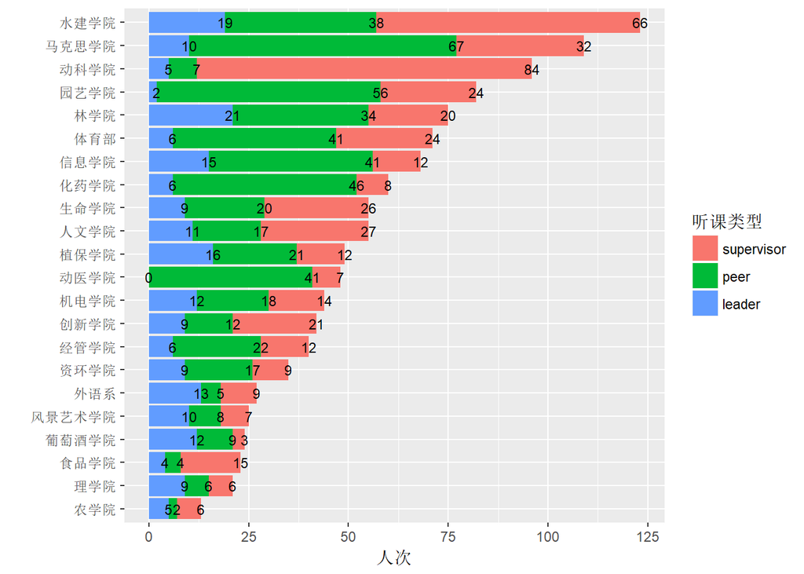

图2.1: 听课情况

其中：supervisor表示督导组听课，peer表示同行专家听课，leader表示领导听课

## 2.2 领导听课情况

领导重视教学情况统计见下表：

表2.2: 领导重视教学情况统计(n=22)

| 序号 | 学院 | 党政领导人数 | 党政领导听课次数 | 党政领导所听授课教师人数 | 领导听课门次占课程总门次的比例% |
| --- | --- | --- | --- | --- | --- |
| 1 | 农学院 | 6 | 5 | 5 | 7.9 |
| 2 | 植保学院 | 6 | 16 | 10 | 43.2 |
| 3 | 园艺学院 | 6 | 2 | 2 | 4.0 |
| 4 | 动科学院 | 7 | 5 | 5 | 10.6 |
| 5 | 动医学院 | 5 | 0 | 0 | 0.0 |
| 6 | 林学院 | 7 | 21 | 16 | 36.2 |
| 7 | 风景艺术学院 | 5 | 10 | 6 | 16.9 |
| 8 | 资环学院 | 7 | 9 | 9 | 10.5 |
| 9 | 水建学院 | 7 | 19 | 12 | 25.0 |
| 10 | 机电学院 | 7 | 12 | 11 | 18.2 |
| 11 | 信息学院 | 5 | 15 | 11 | 28.9 |
| 12 | 食品学院 | 7 | 4 | 4 | 10.3 |
| 13 | 葡萄酒学院 | 5 | 12 | 12 | 60.0 |
| 14 | 生命学院 | 7 | 9 | 9 | 24.3 |
| 15 | 理学院 | 5 | 9 | 8 | 12.9 |
| 16 | 化药学院 | 5 | 6 | 4 | 12.0 |
| 17 | 经管学院 | 6 | 6 | 6 | 6.9 |
| 18 | 人文学院 | 5 | 11 | 10 | 21.1 |
| 19 | 外语系 | 5 | 13 | 13 | 12.8 |
| 20 | 创新学院 | 4 | 9 | 7 | 0.0 |
| 21 | 马克思学院 | 3 | 10 | 7 | 23.8 |
| 22 | 体育部 | 4 | 6 | 6 | 12.5 |

领导重视教学情况柱状图如下：

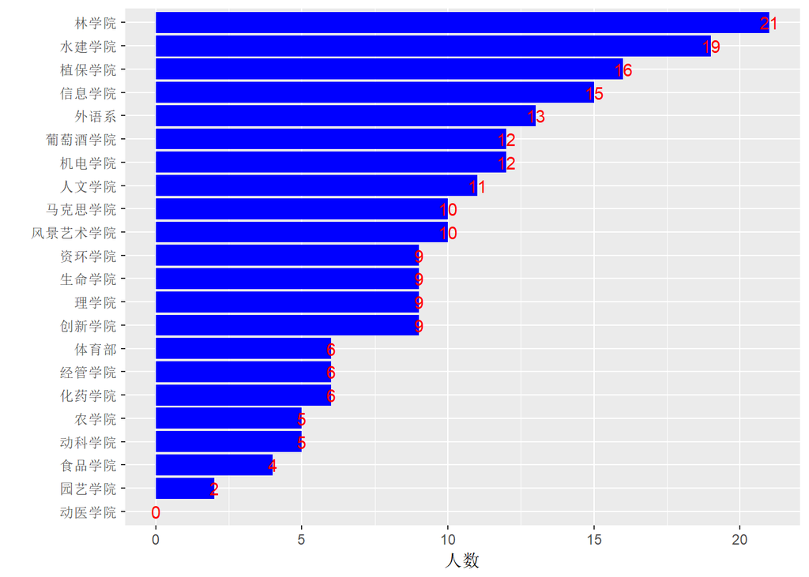

## 2.3 本科工作会议情况

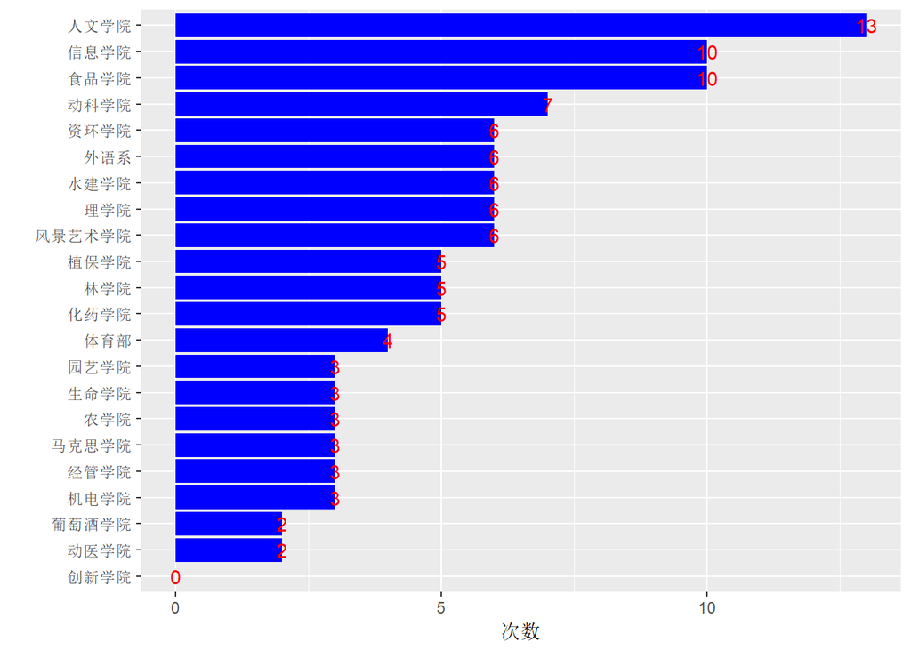

图2.3: 各学院召开教学工作会议情况

全校院系平均召开教学工作会议5.05次.

# 3 课堂教学改革情况

统计表如下：

表3.1: 课堂教学改革情况(n=22)

| 序号 | 学院 | 双语(全英文)计划数 | 双语(全英文)实际数 | 研讨翻转课堂计划数 | 研讨翻转课堂实际数 | 课程考核改革计划数 | 课程考核改革实际数 | 学术讲座(2017秋) | 学术讲座(2018春) | 改革案例数 |
| --- | --- | --- | --- | --- | --- | --- | --- | --- | --- | --- |
| 1 | 农学院 | 0 | 0 | 0 | 1 | 0 | 0 | 19 | 9 | 1 |
| 2 | 植保学院 | 3 | 1 | 0 | 0 | 0 | 0 | 0 | 0 | 1 |
| 3 | 园艺学院 | 1 | 1 | 3 | 1 | 1 | 1 | 0 | 0 | 1 |
| 4 | 动科学院 | 4 | 4 | 1 | 5 | 1 | 3 | 11 | 4 | 4 |
| 5 | 动医学院 | 0 | 0 | 1 | 1 | 1 | 0 | 1 | 4 | 4 |
| 6 | 林学院 | 1 | 2 | 0 | 0 | 0 | 0 | 0 | 3 | 2 |
| 7 | 风景艺术学院 | 0 | 0 | 2 | 2 | 2 | 3 | 4 | 0 | 6 |
| 8 | 资环学院 | 4 | 1 | 2 | 7 | 1 | 4 | 8 | 11 | 3 |
| 9 | 水建学院 | 2 | 2 | 0 | 6 | 0 | 1 | 0 | 1 | 10 |
| 10 | 机电学院 | 0 | 1 | 0 | 0 | 0 | 0 | 2 | 2 | 4 |
| 11 | 信息学院 | 0 | 0 | 1 | 1 | 2 | 1 | 4 | 0 | 1 |
| 12 | 食品学院 | 2 | 2 | 0 | 2 | 0 | 1 | 6 | 4 | 2 |
| 13 | 葡萄酒学院 | 0 | 0 | 4 | 0 | 4 | 1 | 5 | 6 | 1 |
| 14 | 生命学院 | 1 | 5 | 1 | 0 | 2 | 0 | 13 | 19 | 4 |
| 15 | 理学院 | 0 | 0 | 1 | 1 | 2 | 1 | 7 | 1 | 1 |
| 16 | 化药学院 | 0 | 2 | 0 | 0 | 0 | 0 | 2 | 5 | 1 |
| 17 | 经管学院 | 1 | 1 | 0 | 13 | 1 | 3 | 2 | 4 | 4 |
| 18 | 人文学院 | 0 | 0 | 0 | 0 | 0 | 0 | 12 | 6 | 4 |
| 19 | 外语系 | 0 | 56 | 0 | 0 | 0 | 0 | 3 | 2 | 2 |
| 20 | 创新学院 | 0 | 4 | 0 | 6 | 0 | 0 | 0 | 6 | 3 |
| 21 | 马克思学院 | 0 | 0 | 1 | 2 | 1 | 0 | 0 | 0 | 2 |
| 22 | 体育部 | 0 | 0 | 0 | 0 | 0 | 0 | 2 | 2 | 2 |

- 双语(全英文)计划数合计为19,双语(全英文)实际数合计为82
- 研讨翻转课堂计划数合计为17,研讨翻转课堂实际数合计为48
- 课程考核改革计划数合计为18,课程考核改革实际数合计为19
- 学术讲座(2017秋)合计为101,学术讲座(2018春)合计为89

柱状图如下：

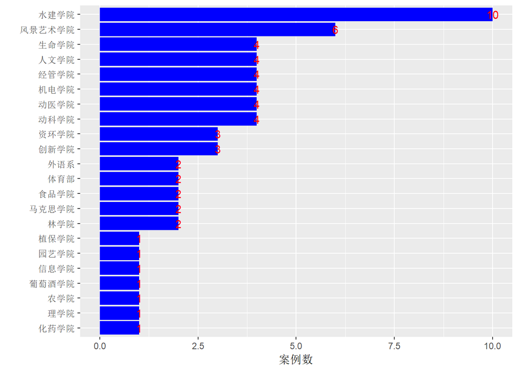

图3.1: 各学院教学改革案例数

# 4 2017-2018学年第二学期期中教学检查总结

为全面深入了解本学期开学以来教学运行状况，及时发现、研究和解决教学运行过程中存在的问题，促进教风与学风建设，提高教学质量，学校于第10-11周组织各教学单位及有关处室开展了本学期期中教学检查工作。各单位及有关处室周密部署，落实检查工作，通过组织召开学生、教师座谈会、实地检查等方式，对本科教学工作进行了全面检查，以查促改，保证了本学期教学工作顺利开展。现将具体情况总结如下：

## 4.1 一、常规教学情况

### 4.1.1 （一）课堂、实践教学秩序良好

通过为期两周的全面检查发现，本学期我校实际开出课程1221门，整体教风良好，教师能严格执行教学进程安排，认真备课，精心准备教案和PPT讲义，教学日历齐备，授课态度认真、能及时批改作业及辅导答疑。大部分学生学习态度端正，听课认真，课堂纪律和课堂气氛良好。 本学期全校开设实验实习课程共计203门，各学院（系）都能认真执行实践教学计划，克服设备仪器陈旧、不足，自主性实习基地缺乏、师资紧张等诸多困难，充分有效利用现有资源完成教学任务，实习、实验课程运行正常。

### 4.1.2 （二）实验室安全运行但仍存隐患

各学院对实验室实验教学条件保障、实验室安全等情况进行了检查。火源管理、易燃物品管理能按照学校的相关规定要求管理，高温设备操作规范，大部分实验楼消防通道畅通，实验室水路配套设施安全。在危险化学用品管理上能做到双人双锁管理、定量登记发放、用后及时收回。但依然有个别学院如机电学院实验设备存放拥挤，存在科研试验挤占了安全通道情况；生命学院生工实训中心存在部分水龙头漏水，用水阀门待维修，压力容器安全超期服役等问题。部分学院实验室存在线路及开关、插座老化现象，机械与电子工程学院、理学院、化药学院实验室下雨墙体渗水，墙面电路有用电安全隐患。

## 4.2 二、重点检查内容情况

### 4.2.2 （二）各学院听课情况

全校院系共有处级干部124人，听课共计209门次，人均听课1.69门次,院系平均听课9.5门次。学院教学督导听课共计444门次，院系平均听课20.18门次。学院同行专家听课共计532门次，院系平均听课24.18门次。学院（系）总平均听课门次为53.86门次，听课次数最多的为水建学院123 门次，其次为马克思主义学院（109门次），最少的为农学院13门次。

本学期共开教学工作会议111次，平均每学院5次会议。教学会议最多的学院为人文学院共13次，其次为信息学院和食品学院，均为10次。

## 4.3 三、存在的问题与建议

### 4.3.1 （一）教学管理工作有待优化

（1）教学管理人员不足、教学管理集中在琐碎的事务性工作，对常规教学研究上精力不足。教学管理系统无更新，严重影响教学工作效率。

（2）管理重心下移，教师承担的事务性工作增多，但缺乏配套的激励措施。

（3）基层教学组织的作用未能很好的发挥出来，实验教学中心的功能在创新人才培养中体现不够。

（4）质量工程数量有待进一步提高，课程建设支持缺乏持续性。

（5）社会评价体系不完善，毕业生及用人单位等社会反馈和跟踪调查体系不完善。

（6） 部分课程安排不合理，尤其是跨校区上课、晚上安排课程师生意见较大。部分专业生物学大实习、工程训练的安排与游泳课教学的冲突。

### 4.3.2 （二）教学有待改进

（1）实习实践条件有待改善。一是教室环境有待改进，当前大部分教室布局设置不适应新型多样的教学模式，不利于师生互动，临近课堂或教室的相互干扰严重。电脑、投影仪等设备老化，也是督导和教师反应最多的问题。例如S206反映多次投影仪和电脑有问题，但直到课程结束，设备都一直未检修好，导致几次课受影响，甚至中途换教室影响上课。南校1号教学楼电脑反应慢且未连网，激光笔失灵。个别多媒体教室投影灯光很暗，老师的课件看不清楚。二是学院稳定的实习基地较少、质量不高，分配实践教学经费不足，个别专业课程缺乏实践基地，如观赏植物实践课程，茶学实验室的面积不够，需补充一间人工气候室等。三是教学实验仪器设备有待更新，部分设备老化影响了正常教学活动致使调课频繁。如信息学院计算机教学实验中心42%的计算机处于淘汰期，现有计算机不但硬件配置低、速度慢，且因长期超负荷使用，随机故障很高，致使5个实验室难以保障当前教学。网络与安全实验室设备使用达13年，故障高发，且实验室空间小，无法满足“网络综合实验”集中实习的课程要求。

（2）优质教学资源不足，省级及以上精品资源共享课、教学成果奖、教学名师、创新实验区等缺乏。

（3）网络课程建设有待加强，网络课程的教学功能没有完全发挥，慕课、微课等网络在线课程较少，且大部分课程仅限于网上布置作业和学生自学，还没有实现完全的在线师生互动。课程考核方式相对较单一，个别学院后半学期课程安排较集中，教师在讲课中有赶课现象。

（4）先行人才培养方案与专业认证标准存在差距，2014版培养方案造成低年级课程多，高年级课程少，希望适当调整。

### 4.3.3 （三）教师队伍有待加强

（1）部分专业教师紧缺，专业课程任务难以落实。如园艺学院观赏园艺、茶学园艺、设施专业的师资不够、食品学院学院具有较强工程实践能力和工程背景的教师比例偏低，毕业生毕业设计占比严重不足，青年教师工程实践能力有待加强。

（2）学科专业领军人才和高水平教学团队缺乏；部分学院专业师资配比不平衡，地理信息科学、人文地理与城乡规划专业教授偏少，尤其人文地理与城乡规划专业师资缺乏，水保专业工程背景师资缺乏。而外语、思政教师课时量过大，教学任务较重。

（3）重科研轻教学现象严重。教师投入教学改革研究的精力不足，基层教学组织内部研讨教学、外出交流培训少。

（4）年轻教师的授课水平和生产实践经验有待提高。个别老师方言较重，外学院部分教师上课状态较差。

（5）教学的形式及方法有待改进，课程课堂气氛不够活跃，个别教师讲课重点与难点不明确，不注重与学生互动、启发学生思维，教学设计、多媒体课件、教学方法和授课技巧有待改进。

### 4.3.4 （四）学风亟须改善

（1）学生的学习纪律性滑坡，特别是上课迟到、旷课、玩手机现象普遍；尤其在高年级学生中更为严重；由于夏季天气炎热，教室闷热，学生在下午前两节课精神不足。

（2）部分学院学生专业学习兴趣和热情不高、转专业意愿强烈。学习主动性有待提高，综合能力、实践技能有待加强，个别学院专业大类分流后，分流后专业整体学风变差。

## 4.4 四、建议

（1）严格调课管理，简化办事流程，加快教学管理的信息化建设，完善更新教务系统，让教学管理人员和教师少跑路。请各项工作应留足学院的教学管理工作时间。

（2）尽量不要在国家法定的节假日安排课程，不应设置调课周频繁调课，学时不足可由教师自行安排补课。

（3）减少各类繁琐表格填报工作，建议狠抓论文质量，简化形式。毕业论文过程管理太繁琐，如毕业论文换题，应该原则上经导师同意后可以换题，只要换题时间5个月以上就可以，而且换题后只需提供导师和学院主管院长签字的换题申请即可，不需要繁琐地重新提交其他一系列开题材料。

（4）加快教室建设，应定期检查，及时维修有问题的教学设备。定期补充和发放扩音器。定期检查，及时维修成绩单打印机。

（5）优化评教体系，尤其是要考虑学生评教人数对评教结果的影响。

（6）加大教学改革项目支持数量，让更多教师有机会参与教学改革，各类评选应充分考虑课程、学科之间的差异。加大大学生创新项目支持力度，提高实验课课时费。

（7）建议尽快启动培养方案修订工作，出台修订原则意见，指导学院修订工作，加强英语教学。